# M07 - Artrite Psoríaca

```
##
##
## Table: Modelos para ADAL60438_injetavel e suas métricas.
##
## |key                 |.model |metrica |        v.0|       v.12|       v.24|
## |:-------------------|:------|:-------|----------:|----------:|----------:|
## |ADAL60438_injetavel |A      |REQM    |  104.05454|  1029.5787|  1259.7451|
## |ADAL60438_injetavel |C      |REQM    |   56.87968|   692.7426|  1111.8027|
## |ADAL60438_injetavel |D      |REQM    |  101.36058|   898.7972|  1528.3419|
## |ADAL60438_injetavel |F      |REQM    |  165.56766|   771.7633|   600.5416|
## |ADAL60438_injetavel |G      |REQM    | 2477.81201|  3594.1881|  3486.8243|
## |ADAL60438_injetavel |A      |winkler |        NaN| 12903.5629| 21707.0693|
## |ADAL60438_injetavel |C      |winkler |        NaN|  9444.4457| 22885.2797|
## |ADAL60438_injetavel |D      |winkler |        NaN| 14413.5378| 33473.3351|
## |ADAL60438_injetavel |F      |winkler |        NaN| 23126.8686| 69457.3391|
## |ADAL60438_injetavel |G      |winkler |        NaN|  9792.1345|  9792.1345|
```

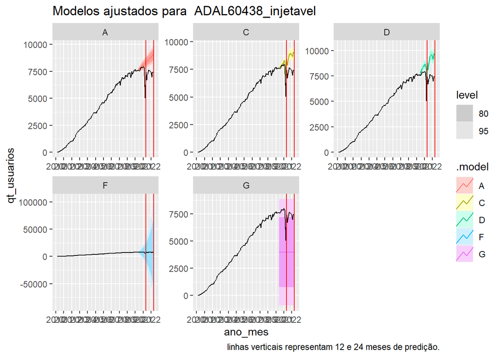

```
##
##
## Table: Modelos para ETAN60438_injetavel e suas métricas.
##
## |key                 |.model |metrica |      v.0|      v.12|      v.24|
## |:-------------------|:------|:-------|--------:|---------:|---------:|
## |ETAN60438_injetavel |B      |REQM    | 79.30696|  165.5897|  225.0541|
## |ETAN60438_injetavel |C      |REQM    | 51.18032|  316.9147|  360.3037|
## |ETAN60438_injetavel |D      |REQM    | 72.62295|  181.8822|  276.4261|
## |ETAN60438_injetavel |E      |REQM    | 79.29318|  167.8558|  228.9770|
## |ETAN60438_injetavel |B      |winkler |      NaN|  659.6209| 1144.1123|
## |ETAN60438_injetavel |C      |winkler |      NaN| 2141.9335| 1972.3587|
## |ETAN60438_injetavel |D      |winkler |      NaN|  677.6542|  986.9402|
## |ETAN60438_injetavel |E      |winkler |      NaN|  644.5827| 1108.4050|
```

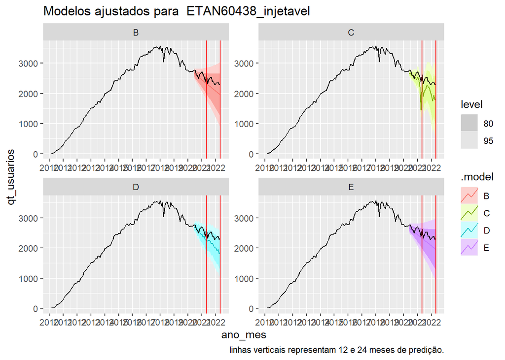

```
##
##
## Table: Modelos para GOLI60438_injetavel e suas métricas.
##
## |key                 |.model |metrica |      v.0|      v.12|      v.24|
## |:-------------------|:------|:-------|--------:|---------:|---------:|
## |GOLI60438_injetavel |A      |REQM    | 14.86334|  92.09681|  245.8913|
## |GOLI60438_injetavel |B      |REQM    | 14.90268|  92.76028|  246.8144|
## |GOLI60438_injetavel |E      |REQM    | 14.95396|  90.72522|  242.4372|
## |GOLI60438_injetavel |F      |REQM    | 16.15205|  80.20380|  215.6183|
## |GOLI60438_injetavel |A      |winkler |      NaN| 651.74685| 4128.7544|
## |GOLI60438_injetavel |B      |winkler |      NaN| 674.82014| 4377.1135|
## |GOLI60438_injetavel |E      |winkler |      NaN| 653.12599| 4154.8272|
## |GOLI60438_injetavel |F      |winkler |      NaN| 571.73740| 1082.9817|
```

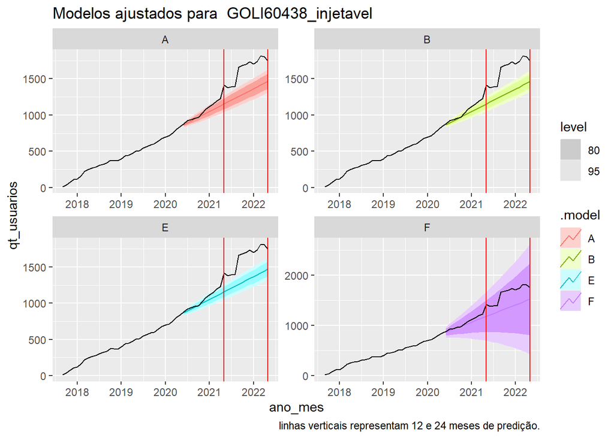

```
##
##
## Table: Modelos para INFL60438_injetavel e suas métricas.
##
## |key                 |.model |metrica |      v.0|      v.12|       v.24|
## |:-------------------|:------|:-------|--------:|---------:|----------:|
## |INFL60438_injetavel |B      |REQM    | 41.54872|  46.59610|   83.42756|
## |INFL60438_injetavel |C      |REQM    | 35.51646| 104.54279|  189.60882|
## |INFL60438_injetavel |D      |REQM    | 39.51842|  45.96071|   50.38385|
## |INFL60438_injetavel |E      |REQM    | 41.49337|  31.01320|   31.41792|
## |INFL60438_injetavel |F      |REQM    | 42.13016|  29.60340|   36.13999|
## |INFL60438_injetavel |B      |winkler |      NaN| 247.55742|  312.02236|
## |INFL60438_injetavel |C      |winkler |      NaN| 449.58224| 1834.05827|
## |INFL60438_injetavel |D      |winkler |      NaN| 369.01553|  522.17859|
## |INFL60438_injetavel |E      |winkler |      NaN| 255.37940|  355.05985|
## |INFL60438_injetavel |F      |winkler |      NaN| 575.69070|  836.44282|
```

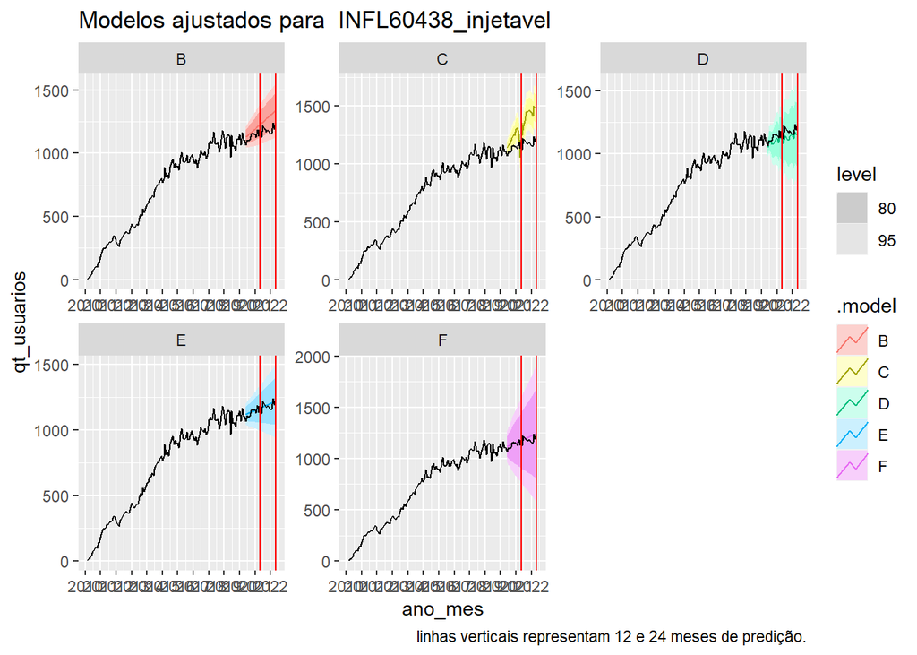

```
##
##
## Table: Modelos para LEFL60432_oral e suas métricas.
##
## |key            |.model |metrica |      v.0|       v.12|      v.24|
## |:--------------|:------|:-------|--------:|----------:|---------:|
## |LEFL60432_oral |C      |REQM    | 25.61977|  186.95641|  328.7470|
## |LEFL60432_oral |D      |REQM    | 28.31117|   84.92895|  153.6055|
## |LEFL60432_oral |F      |REQM    | 31.55165|  125.00973|  257.9858|
## |LEFL60432_oral |C      |winkler |      NaN| 2921.83859| 7840.0146|
## |LEFL60432_oral |D      |winkler |      NaN|  275.91652|  613.0530|
## |LEFL60432_oral |F      |winkler |      NaN|  783.24912| 1096.7664|
```

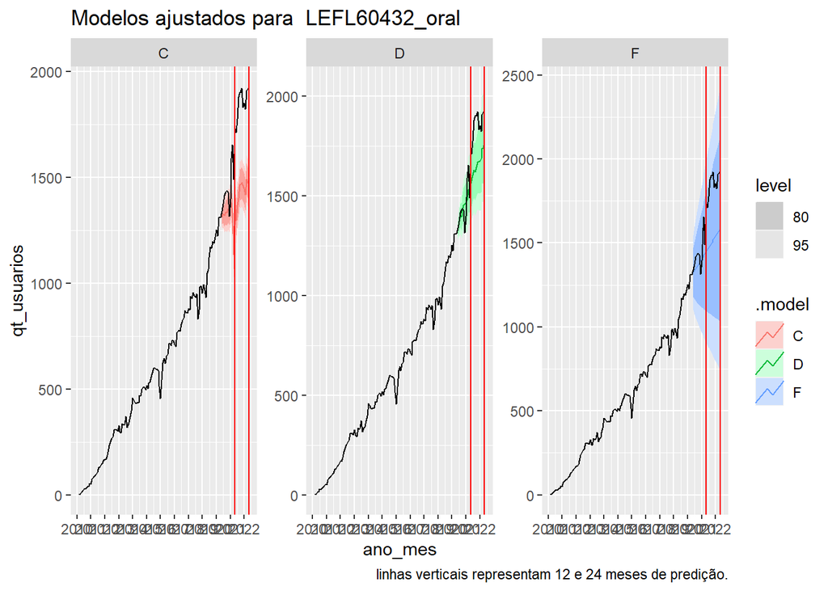

```
##
##
## Table: Modelos para METO60453_injetavel e suas métricas.
##
## |key                 |.model |metrica |      v.0|      v.12|       v.24|
## |:-------------------|:------|:-------|--------:|---------:|----------:|
## |METO60453_injetavel |A      |REQM    | 21.82618|  80.12275|   93.56672|
## |METO60453_injetavel |B      |REQM    | 21.82618|  80.12275|   93.56672|
## |METO60453_injetavel |E      |REQM    | 22.31159|  86.04629|   88.00706|
## |METO60453_injetavel |F      |REQM    | 22.42021|  72.83472|  113.93138|
## |METO60453_injetavel |A      |winkler |      NaN| 347.14639|  429.54875|
## |METO60453_injetavel |B      |winkler |      NaN| 347.14639|  429.54875|
## |METO60453_injetavel |E      |winkler |      NaN| 409.22541|  505.82844|
## |METO60453_injetavel |F      |winkler |      NaN| 757.67241| 1082.74056|
```

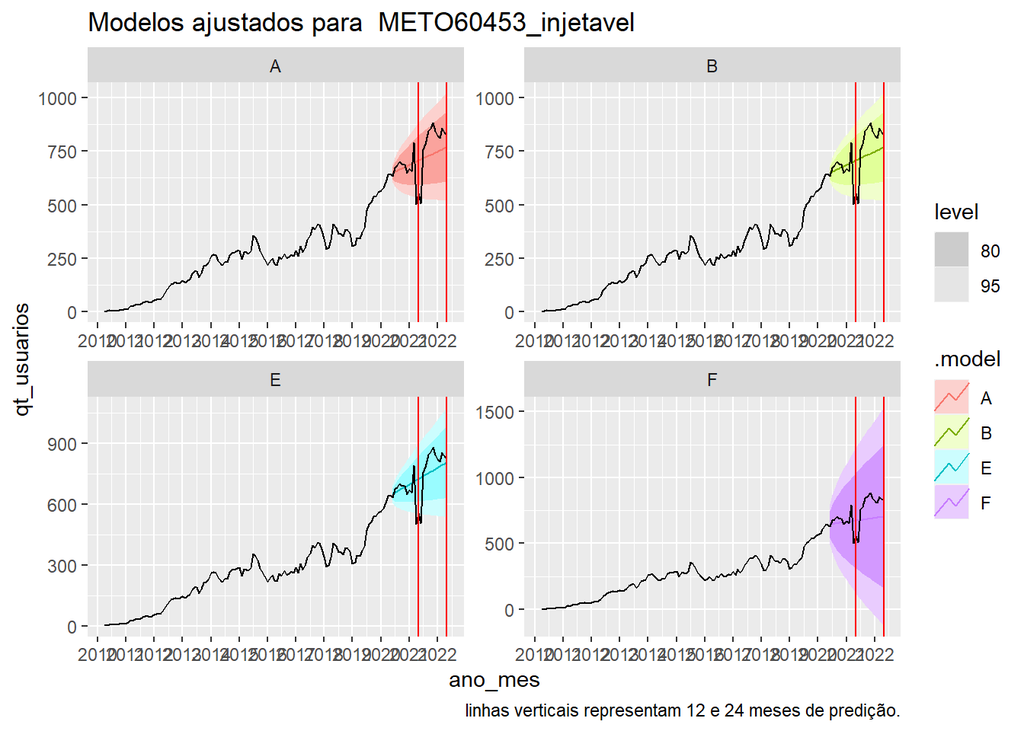

```
##
##
## Table: Modelos para METO60453_oral e suas métricas.
##
## |key            |.model |metrica |      v.0|     v.12|      v.24|
## |:--------------|:------|:-------|--------:|--------:|---------:|
## |METO60453_oral |B      |REQM    | 36.51156| 158.2339|  244.5027|
## |METO60453_oral |E      |REQM    | 36.61079| 161.3071|  250.6192|
## |METO60453_oral |B      |winkler |      NaN| 885.7107| 1069.6205|
## |METO60453_oral |E      |winkler |      NaN| 947.9371| 1262.2034|
```

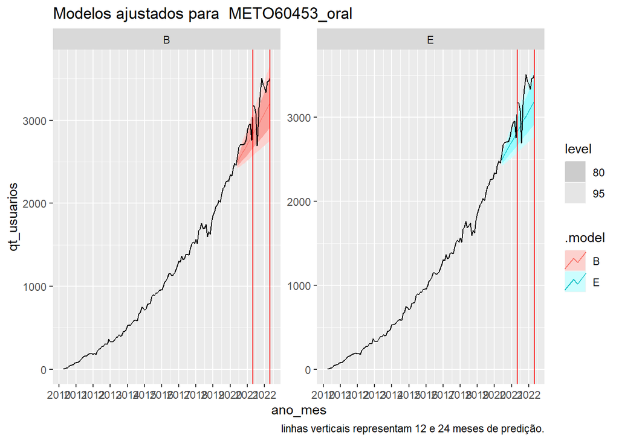

```
##
##
## Table: Modelos para SECU60469_injetavel e suas métricas.
##
## |key                 |.model |metrica |       v.0|       v.12|       v.24|
## |:-------------------|:------|:-------|---------:|----------:|----------:|
## |SECU60469_injetavel |A      |REQM    |  65.15847|  348.06048|   743.5253|
## |SECU60469_injetavel |B      |REQM    |  65.18903|  353.86485|   752.4592|
## |SECU60469_injetavel |F      |REQM    | 107.97298|   97.95081|   132.3654|
## |SECU60469_injetavel |A      |winkler |       NaN| 1751.09583|  8144.2299|
## |SECU60469_injetavel |B      |winkler |       NaN| 1970.99672|  9275.3163|
## |SECU60469_injetavel |F      |winkler |       NaN| 6803.95061| 11204.8911|
```

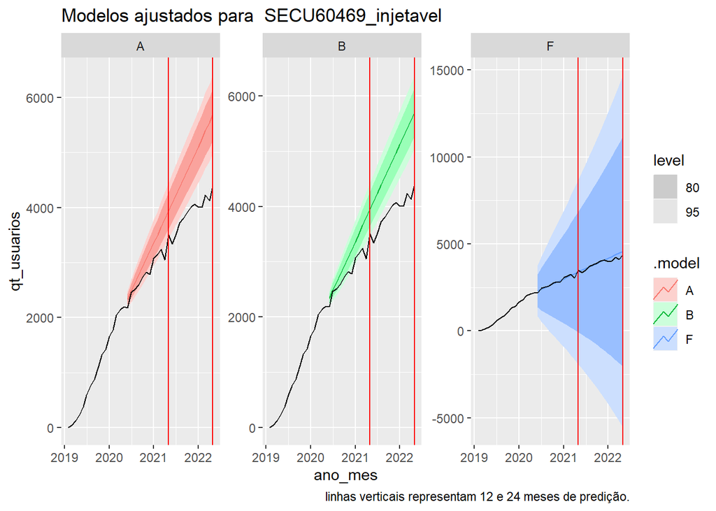

```r
for(i in unique(meds$key)){
  aux <- mm.f.acc %>%
    filter(key == i) %>%
    group_by(key, metrica) %>%
    slice_min(v.0, n = 2, na_rm = T) %>%
    ungroup() %>%
    union(mm.f.acc %>%
            filter(key == i) %>%
            group_by(key, metrica) %>%
            slice_min(v.12, n = 2, na_rm = T) %>%
            ungroup()) %>%
    union(mm.f.acc %>%
            filter(key == i) %>%
            group_by(key, metrica) %>%
            slice_min(v.24, n = 2, na_rm = T) %>% ungroup) %>%
    select(key, .model) %>%
    unique()

  aux %>%
    inner_join(mm.f.acc, by = c("key", ".model")) %>%
    arrange(key, metrica, .model) %>%
    knitr::kable(caption = paste("Modelos para", i, "e suas métricas.")) %>%
    # knitr::kable(caption = paste("Modelos para", i, "e suas métricas."), format = "latex") %>%
    print()

  print(
    meds.cast.24 %>%
      inner_join(aux, by = c("key", ".model")) %>%
      autoplot(meds) +
      scale_x_yearmonth(date_breaks = '1 year', date_labels='%Y') +
      facet_wrap( ~ .model, scales = "free") +
      geom_vline(xintercept = as.Date(max(
        meds.treino$ano_mes
      ) + c(12, 24)), colour = "red") +
      labs(title = paste("Modelos ajustados para ", i),
           caption = "linhas verticais representam 12 e 24 meses de predição.")
  )
}
```

Já as tabelas e gráficos acima apresentam somente os modelos com os melhores REQM e escore Winkler. Sendo eles:

### Adalimumabe

Adalimumabe teve uma diminuição na taxa de difusão ao final da base de treino. Ao final dos primeiros doze meses de observações da base da validação, houve uma queda brusca no número de pacientes. Nenhum modelo foi capaz de predizer esta queda. O modelo que melhor aproximou a média dos dados observados foi o modelo C (ML com erros ARIMA(1,0,4), com os parâmetros qt_concorrentes e qt_total_usuarios) dentro da base da treino e até doze meses. Depois desse período, as médias preditas se distanciaram dos valores observados. Dessa forma, sugere-se o uso do modelo C. A análise dos gráficos corrobora esta decisão. Deve-se ter cautela ao utilizar o método, uma vez que ele depende de uma quantidade desconhecida, a quantidade total de usuários. Esta quantidade deve ser estimada usando o método proposto para demanda aferida, o que agregará maior incerteza.

### Etanercepte

Quando comparados à base de treino, o modelo para etanercepte que teve o melhor desempenho foi o C (ML com erros ARIMA(1,0,4)), com REQM 51.18032, seguido pelo modelo D com REQM 72.62295. Nos períodos de doze e 24 meses, contudo, o modelo C ficou atrás dos demais, tanto em média quanto em intervalo preditivo. Para doze e 24 meses, o modelo B (ARIMA(0,1,1) com drift) teve os melhores REQMs (165.5897 e 225.0541, respectivamente). Por outro lado, os modelos que se destacaram quando avaliados os escores foram os E (suavização exponencial de Holt) para doze meses, com escore 644.5827; e o D (modelo de decomposição em trend + remainder) em 24 meses, com escore 986.9402. Os modelos B e D, no geral, tiveram desempenhos parecidos, tanto em predição da média quanto em intervalos preditivos. Isto posto, o modelo B se aproximou mais dos dados observados de 12 a 24 meses de validação, enquanto o D obteve um intervalo preditivo mais enxuto para 24 meses (escore 986.9402) que o primeiro (1144.1123). Porém, como o modelo D depende de variáveis desconhecidas no momento da estimativa, a variância real dos valores preditos seria maior na prática, em que seriam utilizados valores estimados para um dos parâmetros (qt_total_usuarios). Assim, sugere-se a adoção do modelo B para a predição da difusão de etanercepte.

### Golimumabe

Quatro modelos foram selecionados para avaliação. São eles: A (modelo proposto ARIMA(1,1,0) com drift), B (ARIMA(0,1,0) com drift), E (suavização exponencial de Holt), e F (suavização exponencial com erros multiplicativos). Apesar de os três primeiros se destacarem quando avaliados na base de treino, o modelo F liderou as métricas para todos o período de validação. Isso pode ter acontecido devido a uma alteração na tendência de difusão observada a partir de 2020, que superou as expectativas dos modelos. O modelo F teve melhor aproximação da média para 12 (80.20380 contra média de 91.86077 dos outros modelos) e 24 meses (215.6183 contra média de 245.0476 dos outros modelos). Quanto aos intervalos, o modelo F teve escore 1082.9817, cerca de um quarto dos escores dos modelos concorrentes. É possível observar nos gráficos o desvio que reflete essa diferença de escores: os três primeiros modelos não contêm os dados observados no último ano de predição em seus intervalos preditivos. Por esses motivos, sugere-se o uso do modelo F para a predição de golimumabe, com a ressalva de limitar a utilização a 24 meses, uma vez que a incerteza inerenta a este modelo cresce multiplicativamente com o passar do tempo.

### Infliximabe

Os modelos de suavização exponencial (E e F) se destacaram na predição da difusão de infliximabe. Tanto E (Holt) quanto F (erros multiplicativos) tiveram boas aproximações da média observada nos períodos de 12 (REQM 29.60340 para F) e 24 meses (REQM 31.41792 para E). O modelo E também se destacou quanto ao intervalo preditivo, apesar de não ter os melhores valores absolutos para os escores ( 255.37940 para 12 meses e 355.05985 para 24, contra 247.55742 e 312.02236 do modelo B para os mesmos períodos), figurou em segundo lugar para ambos os períodos. Assim, tendo melhor aproximação da média que o modelo B (ARIMA(0,1,1) com drift), sugere-se o uso da suavização exponencial de Holt para a predição da difusão de infliximabe.

### Leflunomida

Leflunomida teve um modelo que claramente se destacou quanto às métricas avaliadas. O modelo D (ML com erros ARIMA(1,0,0)) teve os melhores REQMs em todo o período de 12 a 24 meses (84.92895 e 153.6055 respectivamente), seguido do modelo F (suavização exponencial com erros multiplicativos) (REQMs 125.00973 e 257.9858 para o mesmo período). Além disso, o modelo D teve os melhores escores: 275.91652 para 12 meses, menos de metade do escore de F (783.24912), e 613.0530 para 24 meses, seguido de F novamente com 1096.7664. Apesar de necessitar de dados desconhecidos no momento da predição (qt_total_usuários), a diferênça entre os modelos parece justificar o uso do modelo D mesmo com a incerteza sobre um dos parâmetros.

### Metotrexato injetavel

O modelo B, ajustado automaticamente pelo método de modelagem, foi o mesmo que o proposto A (ARIMA(1,1,0) com drift). Os dois tiveram também o melhor ajuste da média quando avaliados contra a base de treino. O ARIMA(1,1,0) com drift teve também os melhores escores para até 24 meses, com 347.14639 em doze meses (seguido do modelo E, de Holt, com escore 409.22541) e 429.54875 para 24 meses (seguido novamente do modelo E com escore 505.82844). Apesar de não ter a melhor aproximação da média nestes dois períodos, subestimando os números quanto mais se aproxima do final dos dados, o modelo A é um bom candidato para a predição deste comportamento, seguido do modelo E.

### Metotrexato oral

Os dois modelos mais bem avaliados para metotrexato oral têm desempenhos parecidos, capturando bem a tendência de crescimento. O modelo B (ARIMA(1,2,1)), porém, tem métricas melhores que o modelo E (suavização exponencial de Holt). B tem REQMs mais baixos que E em todos os períodos avaliados, bem como melhores escores para 12 e 24 meses, por exemplo, os REQMs de B e E para 12 meses são 158.2339 e 161.3071, respectivamente; e os escore do mesmo período são 885.7107 para B e 947.9371 para E. O modelo a ser adotado na predição da difusão de metotrexato oral é o B.

### Secuquinimabe

A curva de difusão de secuquinumabe apresentou uma leve diminuição na tendência ao final do período de treino. O número de pacientes permaneceu crescente. Porém, em uma taxa menor que a usada para treinar os modelos. Sendo assim, os modelos A (ARIMA(1,1,0) com drift) e B (ARIMA(0,1,0) com drift) superestimaram a média dos valores até 24 meses preditos. Por outro lado, o modelo F (suavização exponencial com erros multiplicativos) teve uma aproximação média pior na base de treino (REQM 107.97298 contra 65.15847 do modelo A), mas melhores resultados no período predito até 24 meses (REQMs 97.95081 para 12 meses, contra 348.06048 para A; e 132.3654 para 24 meses, contra 743.5253 de A). Ainda assim, devido ao largo intervalo preditivo do modelo, devido aos erros multiplicativos, seus escores foram avaliados acima dos modelos concorrentes: 6803.95061 para doze meses contra 1751.09583 do modelo A; e 11204.8911 em 24 meses, contra 8144.2299 de A. Sendo que nenhum dos modelos teve um desempenho satisfatório e preciso, o ideal seria a remodelagem com dados mais atualizados, uma vez que só se dispõe de dados a partir de 2019 para esta droga. Na necessidade de se predizer a taxa sem a possibilidade de uma nova modelagem, o modelo F seria mais recomendado.

```r
save.image(file = "M07.RData")
```

# Conclusões

Para a modelagem da demanda aferida, sugere-se o uso do modelo A (ARIMA(1,1,0) com drift).

Não foi possível ajustar modelos para certolizumabe pegol, nem para tofacitinibe, por terem poucas observações nos dados. O ideal seria obter cerca de 50 ou mais observações antes de ajustar modelos de séries temporais para ambos.

Para adalimumabe, devido à queda brusca e à alteração subsequente no comportamento da curva, nenhum modelo foi capaz de predizer satisfatoriamente o número de pacientes. Isto posto, o modelo que melhor se ajustou nos primeiros doze meses foi o modelo C (ML com erros ARIMA(1,0,4)). Contudo, deve-se ter cuidado no uso, uma vez que o modelo depende de valores desconhecidos, a serem estimados.

Etanercepte teve dois modelos com desempenhos parecidos: B (ARIMA(0,1,1) com drift) e D (modelo de decomposição em trend e remainder). Porém, este necessita de dados desconhecidos no momento da estimativa, o que aumenta a incerteza. Desta forma, sugere-se a adoção do modelo B para predizer o comportamento de etanercepte.

O único modelo de golimumabe que foi capaz de conter os dados observados em seu intervalo preditivo para mais de 12 meses foi o F (suavização exponencial com erros multiplicativos). Sugere-se o uso deste modelo para a predição da difusão de golimumabe, limitando a predição a 24 meses, pois a incerteza inerente ao modelo cresce rapidamente com predições mais longas.

O modelo que se destacou na predição da difusão de infliximabe foi a suavização exponencial de Holt (modelo E), ainda que tenha escores maiores que os avaliados para o modelo B (ARIMA(0,1,1) com drift), suas predições se aproximaram melhor dos dados observados para 12 e 24 meses.

O modelo de ML com erros ARIMA(1,0,0) (D) ajustado paa leflunomida foi o que teve o melhor desempenho. Sugere-se o uso deste modelo para a predição da difusão de leflunomida, apesar de depender da estimativa do número total de pacientes.

O modelo proposto para metotrexato injetável, ARIMA(1,1,0) com drift (A), foi o mais bem avaliado quando comparado à base de treino bem como avaliado seu intervalo preditivo para 12 e 24 meses. Sugere-se o uso deste modelo para a predição do comportamento do número de pacientes de metotrexato injetável. O modelo E (suavização exponencial de Holt) teve desempenho próximo a este

Para metotrexato oral, o modelo B (ARIMA(1,2,1)) foi o mais bem avaliado em todas as métricas e períodos, seguido pelo modelo de suavização exponencial de Holt (E). Sugere-se a adoção do modelo B para a predição.

Por fim, nenhum modelo foi satisfatório para secuquinumabe. Porém, o modelo F (suavização exponencial com erros multiplicativos) foi o que mais se aproximou dos dados observados, ainda que tenha um intervalo preditivo bastante largo, incluindo números negativos. O ideal seria realizar novos ajustes com observações mais recentes.